# The Impact Of Having Co-morbidities On The Prevalence Rate Of Covid-19 Among Multiple Sclerosis Patients

Ibrahim Al-Fawaz

2025-10-16

[figure not shown]

[figure not shown]

[figure not shown]

# Abstract

**Background:** Multiple sclerosis (MS) is an autoimmune disease of the central nervous system and a leading cause of disability in young adults. The emergence of COVID-19, caused by SARS-CoV-2, has raised concerns about infection risk and outcomes in this vulnerable population. This study aims to evaluate the effect of comorbidities on the prevalence rate of COVID-19 infection among patients diagnosed with multiple sclerosis.

**Objective:** The objective of this study is to evaluate the effect of co-morbidities on the prevalence rate of COVID-19 infection among patients diagnosed with multiple sclerosis.

**Methods:** Cross-sectional analysis of the COVID-19 & MS Global Data Sharing Initiative dataset (n = 1,141 PwMS), which was provided by Cambridge University – Healthcare Data Science Mst Course – and obtained from an open-source repository on GitHub. Association between co-morbidities and infection prevalence was assessed using chi-square testing and odds ratios (95% CI).

**Results:** Females comprised 79.2% (n = 904). Comorbidities were present in 28.7% (n = 328). Overall, 5.3% (n = 60) had confirmed COVID-19. Infection prevalence was 4.4% (36/813) without comorbidities versus 7.3% (24/328) with comorbidities. The chi-square test did not reach conventional significance (p = 0.067). The odds of infection were higher among those with comorbidities (OR ≈ 1.7; 95% CI 1.0–2.9).

**Conclusion:** COVID-19 prevalence in this cohort was low overall. Comorbidities were associated with higher odds of infection, suggesting prevention and optimal management of chronic conditions may reduce risk among MS patients.

# Introduction

Multiple sclerosis (MS) is an autoimmune, inflammatory disorder of the central nervous system and is a major cause of disability among young adults. Patients with MS commonly receive immunomodulatory treatments, which can elevate their risk of infections, as well as infection-related hospitalizations and mortality. The first reported case of COVID-19, caused by the severe acute respiratory syndrome coronavirus 2 (SARS-CoV-2), emerged in Wuhan, China, in December 2019. The virus rapidly spread throughout China and subsequently to countries across the globe. In March 2020, the World Health Organization (WHO) declared COVID-19 a pandemic. As of December 22, 2020, WHO had documented 75,129,306 confirmed cases and 1,680,794 deaths worldwide.(Barzegar et al., 2021)

Current evidence suggests that individuals with autoimmune diseases, including MS, are not inherently at higher risk of contracting SARS-CoV-2. However, the clinical course of COVID-19 in MS patients may differ due to multiple modifying factors. Individuals with MS may experience increased vulnerability related to underlying neurological disability, the immunomodulatory effects of disease-modifying therapies (DMTs), and the potential influence of SARS-CoV-2 on MS disease activity (Louapre et al., 2020). Furthermore, many MS patients require ongoing access to healthcare services such as infusion therapies, physiotherapy, occupational therapy, spasticity management, and home care support. Pandemic-related disruptions to healthcare delivery may therefore complicate disease management, placing some patients at heightened risk (Moss et al., 2020).

In addition to disability and DMT effects, the presence of comorbidities such as hypertension, diabetes mellitus, cardiovascular disease, chronic respiratory disorders, and chronic kidney disease may further modify the risk profile for MS patients during the pandemic (Nandy et al., 2020) . Co-morbidities are known to increase susceptibility to infections and worsen COVID-19 outcomes, which raises the possibility that MS patients with additional chronic health conditions may experience a different infection risk compared with those without co-existing diseases (Nandy et al., 2020).

The likelihood of infection in individuals with MS varies according to the type and mechanism of their DMTs (Luna et al., 2020). Overall, studies suggest that MS patients do not face a substantially higher risk of severe COVID-19, and the incidence of infection in this population remains relatively low (Ghajarzadeh & Bonavita, 2020). However, various factors, including age and comorbidities, are thought to contribute to COVID-19–related morbidity and mortality among patients with MS (Giovannoni et al., 2020). Therefore, this study aims to evaluate the effect of comorbidities on the prevalence rate of COVID-19 infection among patients with MS.

# Methodology

*Study Design*

This is a cross-sectional study that utilized data of 1,141 MS patients from the central platform of the COVID-19 and MS Global Data Sharing Initiative. The dataset underwent extensive de-identification measures, including random shifting of dates by ±15 days and categorization of age into four groups (0 = <18 years, 1 = 18–50, 2 = 51–70, 3 = ≥71). Although these steps protect privacy, they also reduce temporal precision and prevent analysis of exact ages or timelines. Because the data were reported voluntarily using predetermined questionnaire fields, variations in data completeness, self-reporting bias, and inconsistencies in clinical documentation may be present. Furthermore, privacy-preservation techniques such variable generalization may limit analytical granularity and reduce the ability to detect subtle associations.

*Data Governance*

The dataset used in this study was provided as part of the Cambridge University Healthcare Data Science Master course and obtained from a publicly available, de-identified dataset from the COVID-19 and MS Global Data Sharing Initiative hosted on GitHub (Khan, H., Geys, L., baneke, p., Comi, G., & Peeters, 2024).

*Data Variables*

Although the original dataset contained 47 demographic, clinical, and COVID-19–related variables, the present study focused specifically on those relevant to examining the association between comorbidities and confirmed COVID-19 infection. The research question required identifying:

• Exposure variable: has_comorbidities.1, indicating whether the patient had one or more comorbidities.

• Outcome variable: covid19_confirmed_case, indicating a laboratory-confirmed COVID-19 diagnosis.

• Demographic covariates: sex and age_in_cat (categorical age groups).

• Clinical covariates related to MS: ms_type2, current_or_former_smoker, and individual comorbidity indicators including cardiovascular disease, diabetes, hypertension, chronic kidney or liver disease, malignancy, lung disease, immunodeficiency, and neurological or neuromuscular disorders.

These variables were selected because they represent well-established factors influencing infection susceptibility and disease outcomes. Restricting the dataset to these focused fields allowed for clearer hypothesis testing, avoided analytical noise from unrelated variables, and minimized the impact of substantial missingness present in other parts of the dataset (e.g., symptom profiles, DMT specifics, hospital outcomes).

*Statistical Methodology*

Before conducting statistical analyses, the dataset was reviewed and cleaned in Microsoft Excel to ensure accuracy and readiness for analysis. Excel filtering, sorting, and conditional checks were used to screen for inconsistencies, validate categorical labels, and confirm the absence of duplicated case entries.

Descriptive statistics were used to provide an initial overview of the dataset and to present counts and percentages, allowing clear visualization of how variables such as age categories, comorbidity status, confirmed COVID-19 cases, MS type, and smoking status are distributed across groups.

Chi-square was used to test whether a statistically significant association exists between the presence of comorbidities and confirmed COVID-19 infection, as both variables are binary categorical measures. This test examines whether the distribution of COVID-19 outcomes differs between individuals with and without comorbidities beyond what would be expected by chance. In addition, the odds ratio was calculated to quantify the strength and direction of this association, providing a clear measure of how much more (or less) likely MS patients with comorbidities are to have a confirmed COVID-19 infection compared with those without comorbid conditions. All analyses were conducted in R using several packages, including tidyverse for data wrangling and visualization, readxl for data import, dplyr for selecting columns, gtsummary for table and chi-square generation, broom for tidying model outputs, and epitools for calculating odds ratios and confidence intervals.

# Results

In addition to these overall trends, descriptive statistics stratified by sex showed comparable patterns of co-morbidity distribution among females and males. Conditions such as hypertension, diabetes, and lung disease appeared in low but similar proportions across both groups. Relapsing-remitting MS was the predominant phenotype in both sexes, representing 82% of female and 70% of male participants. The visual summary in Figure 1 highlights the proportion of COVID-19 cases within each co-morbidity group, while the forest plot in Figure 2 illustrates the increased odds of infection associated with the presence of comorbidities.

Among participants without comorbidities, 4.4% (n = 36) had a confirmed COVID-19 infection, whereas among those with comorbidities, the proportion was higher at 7.3% (n = 24), indicating a slightly increased proportion of COVID-19 cases in participants with comorbidities compared to those without. The Chi-square test revealed no statistically significant association between comorbidities and COVID-19 infection among MS patients (p-value = 0.067). Nevertheless, patients with comorbidities exhibited a higher infection rate (7.3%) compared with those without (4.4%), suggesting a possible trend toward increased COVID-19 susceptibility in this subgroup (Table 2). MS patients with comorbidities had approximately 1.7 times higher odds of COVID-19 infection compared to those without comorbidities (95% CI: 1.0–2.9) (Figure 2).

*Descriptive statistics*

**Table 1.Summary of COVID-19 MS dataset by Sex**

| **Variable** | **female** N = 904<sup>1</sup> | **male** N = 237<sup>1</sup> |
| --- | --- | --- |
| age_in_cat |  |  |
| 1 | 706 (78%) | 177 (75%) |
| 2 | 198 (22%) | 60 (25%) |
| has_comorbidities.1 |  |  |
| no | 630 (70%) | 183 (77%) |
| yes | 274 (30%) | 54 (23%) |
| covid19_confirmed_case |  |  |
| no | 850 (94%) | 231 (97%) |
| yes | 54 (6.0%) | 6 (2.5%) |
| MS Type |  |  |
| other | 93 (10%) | 38 (16%) |
| progressive_MS | 72 (8.0%) | 32 (14%) |
| relapsing_remitting | 739 (82%) | 167 (70%) |
| Smoker |  |  |
| no | 526 (58%) | 120 (51%) |
| yes | 378 (42%) | 117 (49%) |
| Cardiovascular disease |  |  |
| no | 895 (99%) | 233 (98%) |
| yes | 9 (1.0%) | 4 (1.7%) |
| Chronic kidney disease |  |  |
| no | 900 (100%) | 237 (100%) |
| yes | 4 (0.4%) | 0 (0%) |
| Chronic liver disease |  |  |
| no | 898 (99%) | 233 (98%) |
| yes | 6 (0.7%) | 4 (1.7%) |
| Diabetes |  |  |
| no | 890 (98%) | 234 (99%) |
| yes | 14 (1.5%) | 3 (1.3%) |
| Hypertension |  |  |
| no | 866 (96%) | 222 (94%) |
| yes | 38 (4.2%) | 15 (6.3%) |
| Immunodeficiency |  |  |
| no | 880 (97%) | 232 (98%) |
| yes | 24 (2.7%) | 5 (2.1%) |
| Lung_disease |  |  |
| no | 877 (97%) | 232 (98%) |
| yes | 27 (3.0%) | 5 (2.1%) |
| Malignancy |  |  |
| no | 893 (99%) | 236 (100%) |
| yes | 11 (1.2%) | 1 (0.4%) |
| Neurological_neuromuscular |  |  |
| no | 885 (98%) | 231 (97%) |
| yes | 19 (2.1%) | 6 (2.5%) |

<sup>1</sup> n (%)

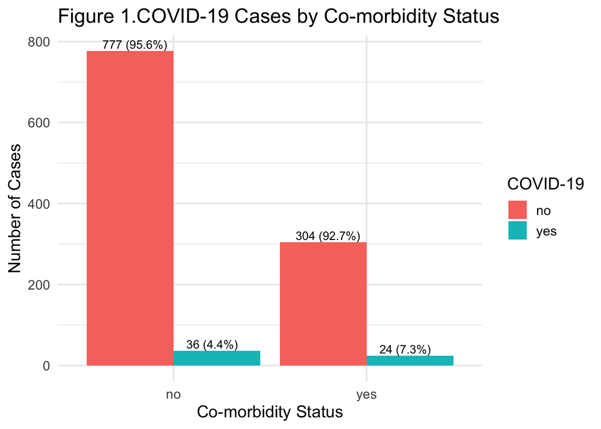

# Formal statistical test of the hypothesis

**Table 2. Association between Co-morbidities and COVID-19 infection**

| **Comorbidities** | covid19_confirmed_case no | covid19_confirmed_case yes | Total | p-value<sup>1</sup> |  |  |
| --- | --- | --- | --- | --- | --- | --- |
| has_comorbidities.1 |  |  |  |  |  | 0.067 |
| no | 777.0 (95.6%) | 36.0 (4.4%) | 813.0 (100.0%) |  |  |  |
| yes | 304.0 (92.7%) | 24.0 (7.3%) | 328.0 (100.0%) |  |  |  |
| Total | 1,081.0 (94.7%) | 60.0 (5.3%) | 1,141.0 (100.0%) |  |  |  |

<sup>1</sup> Pearson’s Chi-squared test

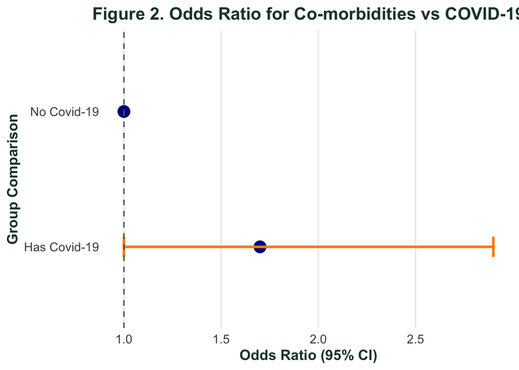

# Discussion

The findings of this study demonstrate that the overall prevalence of COVID-19 infection among patients with MS was relatively low. This observation is consistent with reports from international published literature, which generally suggest that MS alone does not confer an increased risk of contracting COVID-19 (Moghadasi et al., 2021). Several factors may explain this trend, including the high health awareness of individuals with MS, adherence to preventive measures such as social distancing and vaccination, and the careful clinical management provided by neurologists during the pandemic.

Despite the low overall infection rate, the current analysis revealed that MS patients with pre-existing comorbidities were more likely to test positive for COVID-19 compared to those without additional health conditions. This finding aligns with broader epidemiological data indicating that comorbidities such as hypertension, diabetes, cardiovascular disease, and chronic respiratory disorders increase vulnerability to infection and may exacerbate disease severity (Marrie, 2017). In the context of MS, the coexistence of these conditions may further compromise immune function or limit the patient’s physiological resilience against viral infections. These results highlight the importance of viewing MS patients as a heterogeneous group in which co-morbidities play a crucial role in determining infection risk and clinical outcomes.

Beyond the statistical findings, the results of this study also highlight important considerations regarding the interpretation of COVID-19 susceptibility in MS patients. Although the observed association between comorbidities and infection did not reach conventional statistical significance, the elevated odds ratio suggests a clinically meaningful trend that warrants attention. The relatively small number of confirmed COVID-19 cases within the dataset likely reduced the power to detect a significant association. Additionally, reliance on self-reported or clinician-entered data may introduce under-reporting of mild or asymptomatic infections, thereby masking a stronger true association. These patterns reinforce the importance of individualized risk assessment rather than a uniform approach for all MS patients. Individuals with MS who have additional chronic conditions may require targeted preventive strategies, including prioritized vaccination, closer monitoring, and early clinical intervention. Moreover, future research should explore whether specific disease-modifying therapies interact with co-morbidity burden to alter infection risk or severity.

From a clinical and public health perspective, these findings underscore the need for integrated care strategies that address both MS management and co-morbidity control. Routine screening, early identification, and aggressive management of chronic diseases could help reduce infection risk and improve overall health stability among MS patients. Moreover, these insights may guide neurologists and healthcare policymakers in prioritizing preventive measures and vaccination programs for higher-risk subgroups within the MS population. This cross-sectional analysis cannot establish causality. Misclassification of comorbidities or COVID-19 status is possible in secondary datasets. The cohort is international and heterogeneous; country-level differences in testing and care may influence prevalence estimates. The association signal (p = 0.067) was borderline, and the precision around the effect estimate (95% CI 1.0–2.9) indicates uncertainty. Larger, longitudinal studies could clarify temporality and effect modification by disease-modifying therapy.

# Study Limitation

This study has several limitations that should be considered when interpreting the findings. The dataset was collected through a rapid self-report and clinician-report tool, introducing potential reporting bias, misclassification, and inconsistency in documentation, especially for mild COVID-19 cases or incompletely recorded comorbidities. Privacy-preserving steps such as random date shifting and broad categorization of age and disability, while necessary for HIPAA compliance, reduced analytical precision and limited the ability to conduct more granular or temporal analyses. The cross-sectional design prevents establishing causality, and the relatively small number of confirmed COVID-19 cases (n = 60) reduced statistical power.

# Conclusion

In conclusion, although the overall prevalence of confirmed COVID-19 infection within the cohort was low, the findings suggest that MS patients with additional co-morbid conditions demonstrated a modest but notable increase in infection rates compared to those without comorbidities. This pattern aligns with broader evidence indicating that chronic health conditions are associated with heightened vulnerability to infectious diseases, including COVID-19 infection. While the chi-square test did not reach conventional statistical significance, the odds ratio indicated that individuals with comorbidities had approximately 1.7 times higher odds of having the infection, suggesting a clinically meaningful trend that warrants continued observation.

These findings carry important implications for clinical practice, public health strategy, and the management of vulnerable subgroups within the MS population. The interplay between MS, comorbidities, and immunomodulatory therapy complicates risk assessment, necessitating individualized management plans. Healthcare providers should prioritize comprehensive co-morbidity screening, encourage adherence to vaccination programs, and provide targeted counselling to MS patients who may be at elevated risk. Moreover, proactive chronic disease management—including strict control of cardiovascular and metabolic risk factors—may serve as an important protective measure against infectious complications.

Although constrained by methodological and data-related limitations, this study contributes valuable evidence supporting the need for integrated and multidisciplinary care approaches. It also underscores the importance of strengthening global MS registries, improving data completeness, and conducting prospective investigations that can clarify temporal relationships and treatment–risk interactions. Ultimately, protecting the health of MS patients requires ongoing vigilance, tailored preventive strategies, and collaborative efforts across neurology, primary care, and public health systems to mitigate the impact of infectious diseases such as COVID-19.

# References

Barzegar, M., Mirmosayyeb, O., Gajarzadeh, M., Afshari-Safavi, A., Nehzat, N., Vaheb, S., Shaygannejad, V., & Maghzi, A.-H. (2021). COVID-19 Among Patients With Multiple Sclerosis. Neurology Neuroimmunology &amp; Neuroinflammation, 8(4), e1001. https://doi.org/10.1212/NXI.0000000000001001

Louapre, C., Collongues, N., Stankoff, B., Giannesini, C., Papeix, C., Bensa, C., Deschamps, R., Créange, A., Wahab, A., & Pelletier, J. (2020). Clinical characteristics and outcomes in patients with coronavirus disease 2019 and multiple sclerosis. JAMA Neurology, 77(9), 1079–1088.

Moss, B. P., Mahajan, K. R., Bermel, R. A., Hellisz, K., Hua, L. H., Hudec, T., Husak, S., McGinley, M. P., Ontaneda, D., Wang, Z., Weber, M., Tagliani, P., Cárdenas-Robledo, S., Zabalza, A., Arrambide, G., Carbonell-Mirabent, P., Rodríguez-Barranco, M., Sastre-Garriga, J., Tintore, M., … Fitzgerald, K. C. (2020). Multiple sclerosis management during the COVID-19 pandemic. Multiple Sclerosis Journal, 26(10), 1163–1171. https://doi.org/10.1177/1352458520948231

Nandy, K., Salunke, A., Pathak, S. K., Pandey, A., Doctor, C., Puj, K., Sharma, M., Jain, A., & Warikoo, V. (2020). Coronavirus disease (COVID-19): A systematic review and meta-analysis to evaluate the impact of various comorbidities on serious events. Diabetes & Metabolic Syndrome: Clinical Research & Reviews, 14(5), 1017–1025. https://doi.org/https://doi.org/10.1016/j.dsx.2020.06.064

Luna, G., Alping, P., Burman, J., Fink, K., Fogdell-Hahn, A., Gunnarsson, M., Hillert, J., Langer-Gould, A., Lycke, J., Nilsson, P., Salzer, J., Svenningsson, A., Vrethem, M., Olsson, T., Piehl, F., & Frisell, T. (2020). Infection Risks Among Patients With Multiple Sclerosis Treated With Fingolimod, Natalizumab, Rituximab, and Injectable Therapies. JAMA Neurology, 77(2), 184–191. https://doi.org/10.1001/jamaneurol.2019.3365

Ghajarzadeh, M., & Bonavita, S. (2020). Are patients with multiple sclerosis (MS) at higher risk of COVID-19 infection? Neurological Sciences, 41(9), 2315–2316. https://doi.org/10.1007/s10072-020-04570-8

Giovannoni, G., Hawkes, C., Lechner-Scott, J., Levy, M., Waubant, E., & Gold, J. (2020). The COVID-19 pandemic and the use of MS disease-modifying therapies. Multiple Sclerosis and Related Disorders, 39, 102073. https://doi.org/10.1016/j.msard.2020.102073

Khan, H., Geys, L., baneke, p., Comi, G., & Peeters, L. (2024). (2024). Patient-level dataset to study the effect of COVID-19 in people with Multiple Sclerosis. PhysioNet. RRID:SCR_007345. https://doi.org/https://doi.org/10.13026/77ta-1866

Moghadasi, A. N., Mirmosayyeb, O., Barzegar, M., Sahraian, M. A., & Ghajarzadeh, M. (2021). The prevalence of COVID-19 infection in patients with multiple sclerosis (MS): a systematic review and meta-analysis. Neurological Sciences, 42(8), 3093–3099. https://doi.org/10.1007/s10072-021-05373-1

Marrie, R. A. (2017). Comorbidity in multiple sclerosis: implications for patient care. Nature Reviews Neurology, 13(6), 375–382. https://doi.org/10.1038/nrneurol.2017.33